# Fantasy Football Analysis

Justin Welsh, Patrick Passarello

## Introduction

The National Football League was founded in 1920 as a means to standardize the rules and regulations of the sport and elevate the game from a schoolyard pastime to a national business. By the mid-1960s, football was the most popular sport in America. The advent of cable television brought the sport into every home in America. Since then, millions have enjoyed watching their favorite teams compete every Sunday.  
Fantasy football arose as a natural outcome to the rise of the role of data in professional sports. In its most basic form, fantasy football is a game which tracks stats of every NFL player each week and awards points based on how well a player performs. Performance metrics include number of receptions, passing, receiving, and rushing yards, and number of touchdowns. A typical fantasy football league starts with a draft in which league members pick from a list of all NFL players, ranked based on their projected stats for the upcoming season. From these players, they create a lineup of 1 quarterback (QB), 2 running backs (RB), 2 wide receivers (WR), 1 tight end (TE), 1 flex player (RB, WR, or TE), 1 defense (D/ST), and 1 kicker (K). Each week, members put their lineups to the test by going head to head with others in their league to score the most points. League members can try to improve their team throughout the season by adding available players who have not been claimed by other teams or orchestrating trades with other league members.  
Thus, to succeed in fantasy football, we need to be able to accurately predict which players will perform the best not only each week, but throughout the entire season. The data itself is available to everyone; the key to success is taking the data and determining which parts are meaningful and which are not. In this data science tutorial, we will discuss in detail the process which data scientists take to answer questions such as these.  
Another important note is that there are many different rules for defining how points are earned and how many points are awarded for different feats. More information on the main 2 types of point systems can be found [here](https://www.nbcsports.com/boston/fantasy-football/fantasy-football-ppr-vs-standard-scoring-leagues-explained). For this project we will be looking at the PPR scoring format which stands for points per reception. The main caveat with this scoring scheme is that a player gets a point for every time they get a reception. This often changes the value of a player since players can get many receptions in a game.

## Part 1 & 2: Data Collection and Data Cleaning

Our first step after identifying a subject and question to answer is to locate a publicly available data source (or make our own!). We will search with a few criteria in mind:

- Ensure that the number of data points is sufficient for analysis (if we have data on most players across multiple seasons it will be sufficient).
- Ensure that the dataset has the elements we need (such as performance metrics).
- Ensure data is not too messy that it will be cumbersome to use.
- Be flexible! You may not be able to find the exact dataset you want, but what you are able to find may lead you in a new or better direction.

Also in this stage of the data science pipeline is necessary to prepare the data and the way in which it is stored for further analysis. Think of this as the *preprocessing* step. In this step, we should try to look for a few things:

- Is there data which is clearly missing?
- Are there any labels in our dataset which can be considered extraneous or unnecessary?
- Is our data stored or represented in such a way that will allow for efficient analysis and visualization?

Within this project you will see this step pop up sporadically throughout our project. This is because when trying to use data from different sources there can minor differences in the way that each source stored the data which doesn't make that source bad or unuseable, it just means you are going to have to do a little bit of extra work so that the 2 sources are compatible with each other. This is why we combine the first and 2 steps of the pipline. Within the most of the functions we define for data collection, we clean the data in different ways before we return the dataframe. This is so that when we use the data later in the project we will have don't have to do this tidying.

First, we will import all the Python libraries which are helpful for data analysis and visualization

```python
import numpy as np
import pandas as pd
import matplotlib.pyplot as plt
import requests
from sklearn import linear_model
from sklearn.metrics import max_error, mean_squared_error, mean_absolute_error, precision_score, recall_score

import warnings
warnings.filterwarnings(action='ignore')
```

Next, we will load in our dataset(s).  
It's important to note that it is not always easy to find easily accessible CSV data when we are looking for a dataset. Sometimes, we will need to get our hands dirty and use techniques such as *web scraping*. Web scraping is a process by which we can retrieve data from static html pages on the internet. It is typically used as a last resort when there is no dataset available or if the website doesn't have an API set up for us to use. Read more about web scraping in Python [here](https://www.geeksforgeeks.org/python-web-scraping-tutorial/).

After searching the web, we found a several great sources for fantasy football data. The first one comes from a hosted publicly on GitHub [here](https://github.com/fantasydatapros/data). This dataset provides a wide variety of NFL statistics that we utilizein this project. The next place we pull data from is https://fantasyfootballcalculator.com. This site provides an archive of a statistic called ADP that we explain later. The final place we get our data from is www.pro-football-reference.com. This site has an expansive database on both players and team statistics

Below, we will define a number of functions which will help us read in the CSV files from the two data sources. Keep in mind that we may need to do some additional tidying within these functions to make the datasets more usable! It is rarely the case that we are able to find a perfect dataset.  
*Takeaway: Think about the most efficient ways to read in data! In Python, it can sometimes be helpful to write a function to do the heavy lifting!*

One major thing we did for cleaning was to define a dictionary that associates each team name with its 3 letter abbreviation. This helps us clean the data since it allows us to match the data later on since some of our data sources don't use the same identifier for the team that a player is on. In this step we also account for when teams change names which is why some abbreviations have more than one team name that maps to it. For example the abreviation **WAS** has both the Football Team and the Redskins that map to it.

```python
# dictionary of team abbreviations
team_abrv_dict = {
    'Tampa Bay Buccaneers': 'TAM',
    'Carolina Panthers': 'CAR',
    'Atlanta Falcons': 'ATL',
    'New Orleans Saints': 'NOR',
    'Jacksonville Jaguars': 'JAX',
    'Indianapolis Colts': 'CLT',
    'San Francisco 49ers': 'SFO',
    'Tennessee Titans': 'OTI',
    'Minnesota Vikings': 'MIN',
    'Philadelphia Eagles': 'PHI',
    'Chicago Bears': 'CHI',
    'Los Angeles Chargers': 'SDG',
    'San Diego Chargers': 'SDG',
    'Dallas Cowboys': 'DAL',
    'New York Giants': 'NYG',
    'Green Bay Packers': 'GNB',
    'Detroit Lions': 'DET',
    'Denver Broncos': 'DEN',
    'New England Patriots': 'NWE',
    'Los Angeles Rams': 'RAM',
    'St. Louis Rams': 'RAM',
    'Arizona Cardinals': 'CRD',
    'Seattle Seahawks': 'SEA',
    'Oakland Raiders': 'RAI',
    'Las Vegas Raiders': 'RAI',
    'Houston Texans': 'HTX',
    'Washington Redskins': 'WAS',
    'Washington Football Team': 'WAS',
    'Baltimore Ravens': 'RAV',
    'Buffalo Bills': 'BUF',
    'Kansas City Chiefs': 'KAN',
    'New York Jets': 'NYJ',
    'Pittsburgh Steelers': 'PIT',
    'Cincinnati Bengals': 'CIN',
    'Cleveland Browns': 'CLE',
    'Miami Dolphins': 'MIA'
}
team_abrv_list = [
  'BUF', 'MIA', 'NWE', 'NYJ',
  'RAV', 'PIT', 'CLE', 'CIN',
  'OTI', 'CLT', 'HTX', 'JAX',
  'KAN', 'RAI', 'SDG',  'DEN',
  'WAS', 'NYG', 'DAL', 'PHI',
  'GNB', 'CHI', 'DET', 'MIN',
  'NOR', 'TAM', 'CAR', 'ATL',
  'CRD', 'SFO', 'SEA', 'RAM'
]
```

This first function pulls data from the FantasyPros github that we listed above and it allows us to get a dataframe containing all the relevent stats and fantasy data for all NFL players for a given year.

```python
def get_yearly_data(year: int) -> pd.DataFrame:
  #Input: Desired NFL season (int)
  #Returns:  Player data from desired season (pd.DataFrame)
  if 1970 <= year <= 2020:
    url = (
        'https://raw.githubusercontent.com/fantasydatapros/data/master/yearly/'
        + str(year)
        + '.csv'
    )
    df = pd.read_csv(url)

    # Cleaning data since the initials for some of the teams are different
    # over the years or are different from the abbreviations used in other
    # datasets that we use
    df.Tm[df.Tm == 'BAL'] = 'RAV'
    df.Tm[df.Tm == 'IND'] = 'CLT'
    df.Tm[df.Tm == 'TEN'] = 'OTI'
    df.Tm[df.Tm == 'OAK'] = 'RAI'
    df.Tm[df.Tm == 'LVR'] = 'RAI'
    df.Tm[df.Tm == 'STL'] = 'RAM'
    df.Tm[df.Tm == 'LAR'] = 'RAM'
    df.Tm[df.Tm == 'HOU'] = 'HTX'
    df.Tm[df.Tm == 'ARI'] = 'CRD'
    df.Tm[df.Tm == 'LAC'] = 'SDG'

    # don't include players that are not on a team
    # df = df.loc[df['Tm'].isin(team_abrv_list)]
    # only include players with one of the positions we are looking at
    # df = df.loc[(df['Pos'] == 'QB') |
                # (df['Pos'] == 'RB') |
                # (df['Pos'] == 'WR') |
                # (df['Pos'] == 'TE')]

    return df
  else:
    print('Year provided not in dataset; Please select a year between 1970-2020')
    return None
```

This first function pulls data from the FantasyPros github that we listed above and it allows us to get a dataframe containing all the relevent stats and fantasy data for all NFL players for a given year.

```python
year_df = get_yearly_data(2020)
year_df.head()
```

|  | Player | Tm | Pos | Age | G | GS | Tgt | Rec | PassingYds | PassingTD | PassingAtt | RushingYds | RushingTD | RushingAtt | ReceivingYds | ReceivingTD | FantasyPoints | Int | Fumbles | FumblesLost |
| --- | --- | --- | --- | --- | --- | --- | --- | --- | --- | --- | --- | --- | --- | --- | --- | --- | --- | --- | --- | --- |
| 0 | Derrick Henry | OTI | RB | 26 | 16 | 16 | 31 | 19 | 0 | 0 | 0 | 2027 | 17 | 378 | 114 | 0 | 314.0 | 0 | 3 | 2 |
| 1 | Alvin Kamara | NOR | RB | 25 | 15 | 10 | 107 | 83 | 0 | 0 | 0 | 932 | 16 | 187 | 756 | 5 | 295.0 | 0 | 1 | 0 |
| 2 | Dalvin Cook | MIN | RB | 25 | 14 | 14 | 54 | 44 | 0 | 0 | 0 | 1557 | 16 | 312 | 361 | 1 | 294.0 | 0 | 5 | 3 |
| 3 | Travis Kelce | KAN | TE | 31 | 15 | 15 | 145 | 105 | 4 | 0 | 2 | 0 | 0 | 0 | 1416 | 11 | 208.0 | 0 | 1 | 1 |
| 4 | Davante Adams | GNB | WR | 28 | 14 | 14 | 149 | 115 | 0 | 0 | 0 | 0 | 0 | 0 | 1374 | 18 | 243.0 | 0 | 1 | 1 |

This next function also pulls data from the github source and provides us with a data frame about each teams strength of schedule for that year. Strength of schedule is a measure of hard a teams schedule was for that given year. It looks at each defense a team faced in a season and measures how fantasy points that defense gave up throughout the year to give a measure of how difficult a team's schedule was.

```python
def get_sos_data(year: int) ->pd.DataFrame:
  if 1999 <= year <= 2019:
    url = (
        'https://raw.githubusercontent.com/fantasydatapros/data/master/sos/'
        + str(year)
        + '.csv'
    )
    df = pd.read_csv(url)
    df = df.rename(columns={"Unnamed: 0": "Team"})
    return df
  else:
    print('Year provided not in dataset; Please select a year between 1999-2020')
    return None
```

```python
sos_df = get_sos_data(2019)
sos_df.head()
```

|  | Team | OppPPRFantasyPointsAllowed | PPRSOSRank | OppStandardFantasyPointsAllowed | StandardSOSRank | OppHalfPPRFantasyPointsAllowed | HalfPPRSOSRank | OppRushingFantasyPointsAllowed | RushingSOSRank | OppPassingFantasyPointsAllowed | PassingSOSRank | OppPPRReceivingFantasyPointsAllowed | PPRReceivingSOSRank | OppHalfPPRReceivingFantasyPointsAllowed | HalfPPRReceivingSOSRank | OppStandardReceivingFantasyPointsAllowed | StandardReceivingSOSRank |
| --- | --- | --- | --- | --- | --- | --- | --- | --- | --- | --- | --- | --- | --- | --- | --- | --- | --- |
| 0 | Tampa Bay Buccaneers | 22724.14 | 32.0 | 16884.14 | 32.0 | 19804.14 | 32.0 | 4193.2 | 32.0 | 3836.84 | 31.0 | 14694.1 | 30.0 | 11774.1 | 31.0 | 8854.1 | 31.0 |
| 1 | Carolina Panthers | 22410.24 | 31.0 | 16501.24 | 30.0 | 19455.74 | 31.0 | 3735.5 | 4.0 | 3855.64 | 32.0 | 14819.1 | 32.0 | 11864.6 | 32.0 | 8910.1 | 32.0 |
| 2 | Atlanta Falcons | 22364.40 | 30.0 | 16418.40 | 26.0 | 19391.40 | 28.0 | 3890.7 | 15.0 | 3764.20 | 29.0 | 14709.5 | 31.0 | 11736.5 | 30.0 | 8763.5 | 29.0 |
| 3 | New Orleans Saints | 22344.92 | 29.0 | 16448.92 | 29.0 | 19396.92 | 29.0 | 4047.3 | 25.0 | 3735.32 | 27.0 | 14562.3 | 28.0 | 11614.3 | 28.0 | 8666.3 | 27.0 |
| 4 | Jacksonville Jaguars | 22271.16 | 28.0 | 16448.16 | 28.0 | 19359.66 | 27.0 | 3842.7 | 8.0 | 3797.56 | 30.0 | 14630.9 | 29.0 | 11719.4 | 29.0 | 8807.9 | 30.0 |

Our final function pulls data from local csv files that were downloaded from https://fantasyfootballcalculator.com. This function returns data on a players average draft position or ADP. This means out of many different leagues, at what position was a player taken on average in all of those drafts.

```python
def get_adp_by_year(year: int) -> pd.DataFrame:
  # data from https://fantasyfootballcalculator.com/adp/ppr/12-team/all/2020
  adp_df = pd.read_csv(str(year) + 'adp.csv')

  # replace certain team names so they match up with our other data frames
  adp_df.Team[adp_df.Team == 'BAL'] = 'RAV'
  adp_df.Team[adp_df.Team == 'IND'] = 'CLT'
  adp_df.Team[adp_df.Team == 'TEN'] = 'OTI'
  adp_df.Team[adp_df.Team == 'LV'] = 'RAI'
  adp_df.Team[adp_df.Team == 'GB'] = 'GNB'
  adp_df.Team[adp_df.Team == 'LAR'] = 'RAM'
  adp_df.Team[adp_df.Team == 'HOU'] = 'HTX'
  adp_df.Team[adp_df.Team == 'ARI'] = 'CRD'
  adp_df.Team[adp_df.Team == 'LAC'] = 'SDG'
  adp_df.Team[adp_df.Team == 'SF'] = 'SFO'
  adp_df.Team[adp_df.Team == 'KC'] = 'KAN'
  adp_df.Team[adp_df.Team == 'NO'] = 'NOR'
  adp_df.Team[adp_df.Team == 'NE'] = 'NWE'
  adp_df.Team[adp_df.Team == 'TB'] = 'TAM'

  # clean up data
  adp_df.rename(columns={'Name': 'Player'}, inplace=True)
  adp_df.drop(['Column1'], axis = 1, inplace=True)

  # don't include players that are not on a team
  adp_df = adp_df.loc[adp_df['Team'].isin(team_abrv_list)]
  # only include players in the posititions that we are interested in
  adp_df = adp_df.loc[(adp_df['Pos'] == 'QB') |
                (adp_df['Pos'] == 'RB') |
                (adp_df['Pos'] == 'WR') |
                (adp_df['Pos'] == 'TE')]

  # clean the data so that all the names match up
  adp_df.Player[adp_df.Player == 'Joshua Cribbs'] = 'Josh Cribs'
  adp_df.Player[adp_df.Player == 'Robert Griffin III'] = 'Robert Griffin'
  adp_df.Player[adp_df.Player == 'LeVeon Bell'] = 'Le\'Veon Bell'
  adp_df.Player[adp_df.Player == 'CJ Anderson'] = 'C.J. Anderson'
  adp_df.Player[adp_df.Player == 'TJ Yeldon'] = 'T.J. Yeldon'
  adp_df.Player[adp_df.Player == 'Ted Ginn Jr'] = 'Ted Ginn'
  adp_df.Player[adp_df.Player == 'Rob Kelley'] = 'Robert Kelley'
  adp_df.Player[adp_df.Player == 'CJ Prosise'] = 'C.J. Prosise'
  adp_df.Player[adp_df.Player == 'Ronald Jones II'] = 'Ronald Jones'
  adp_df.Player[adp_df.Player == 'Mitch Trubisky'] = 'Mitchell Trubisky'
  adp_df.Player[adp_df.Player == 'Odell Beckham Jr'] = 'Odell Beckham'
  if year == 2020:
    adp_df.Player[adp_df.Player == 'A.J. Dillon'] = 'AJ Dillon'
    adp_df.Player[adp_df.Player == 'Odell Beckham Jr'] = 'Odell Beckham Jr.'
    adp_df.Player[adp_df.Player == 'D.J. Chark'] = 'DJ Chark'
    adp_df.Player[adp_df.Player == 'Chris Herndon IV'] = 'Chris Herndon'
    adp_df.Player[adp_df.Player == 'Gardner Minshew'] = 'Gardner Minshew II'
    adp_df.Player[adp_df.Player == 'Ronald Jones'] = 'Ronald Jones II'
  return adp_df
```

Within this function we so a lot of tidying on the data. This is because we are pulling data from a different site that our other data frames come from so there are small dicrepencies between the data so they don't match up perfectly, particularly the team and player names. Also, we based on the team name but we also filter out some data that is not applicable to our project. Specifically, we filter out data based on players that are actually on a team because we are not interested in players that are not on a team since they won't be scoring any points. Also we filter out the players that are not in the positions that we are looking for.

```python
adp_df = get_adp_by_year(2020)
adp_df.head()
```

|  | # | Pick | Player | Pos | Team | Overall | StdDev | High | Low | TimesDrafted |
| --- | --- | --- | --- | --- | --- | --- | --- | --- | --- | --- |
| 0 | 1 | 1.01 | Christian McCaffrey | RB | CAR | 1.2 | 0.5 | 1.01 | 1.04 | 936 |
| 1 | 2 | 1.03 | Saquon Barkley | RB | NYG | 2.5 | 0.7 | 1.01 | 1.06 | 960 |
| 2 | 3 | 1.03 | Ezekiel Elliott | RB | DAL | 3.4 | 1.6 | 1.01 | 1.11 | 521 |
| 3 | 4 | 1.05 | Alvin Kamara | RB | NOR | 4.9 | 1.3 | 1.01 | 1.12 | 960 |
| 4 | 5 | 1.06 | Michael Thomas | WR | NOR | 5.6 | 1.6 | 1.01 | 1.11 | 811 |

## Part 3: Exploratory Data Analysis

The importance of exploratory data analysis cannot be overstated. It is crucial that we as data scientists are able to visualize the data and identify certain initial trends, which may even present us with new questions to answer. Visualization is an important tool which we have at our disposal; it allows us to observe certain trends that we may not be able to discern simply from looking at the dataset (especially if the dataset in question is particularly large). In Python, we can use either the *matplotlib* or *seaborn* libraries for plotting the data

### Strength of Schedule

One thing we wanted to look at was defensive matchups. This is because fantasy football experts often talk about how matchups are big factor in player success and recommend to start players that have a favorable matchup. By following that logic you would think that players that have easier schedules would typically be more successful than those with harder schedules.

For this part of our data exploration we decided to split it up by position. This is because each position scores points from doing different things. For example a Quarterback typically doesn't score points from receptions or receiving yards, most of thier points come from passing yards or passing touchdowns. A similar arguement can be made for all of the other positions as well and because of this we decided to look at the positions independently.

In order to look at this we pulled data on each players fantasty stats for a given year and plotted that against the strength of that players schedule. This required us to match the team each player was on to the strength of schedule data which wasn't straight forward since the strength of scedule(SOS) data only listed the full names of the teams while the yearly data only listed the team abbreviation. So in order to map the SOS data to the yearly data we used the dictionary that is defined above. Also, we don't include any players that have 0 fantasy points for that week. This is because our data includes many people that don't ever start and don't score any points so we shouldn't include them. Finally, we also don't include players that switched teams mid-season. This is because our data doesn't tell us what teams the players switched to, it only says that they were on 2 or maybe 3 teams in a season.

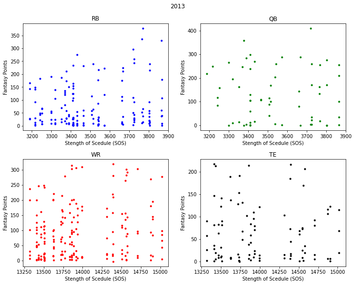

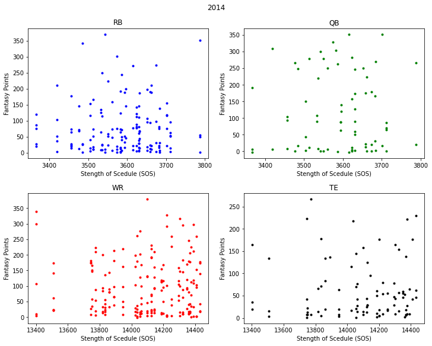

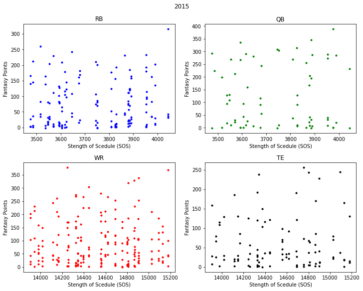

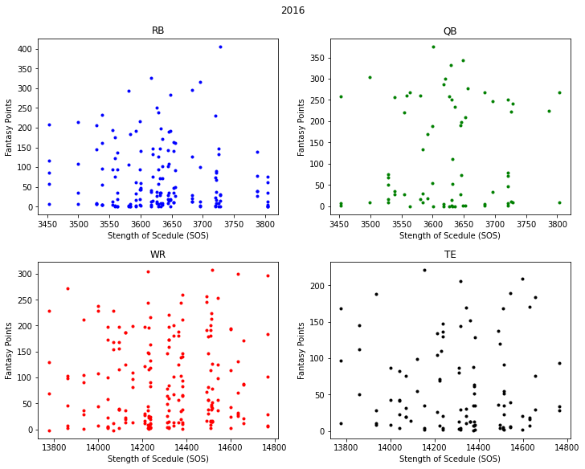

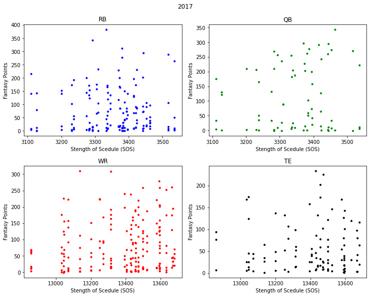

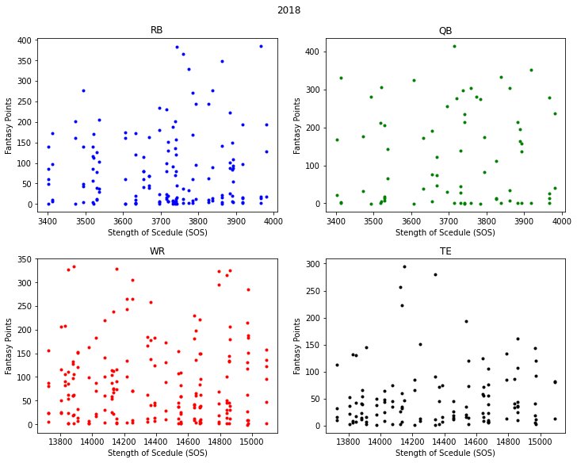

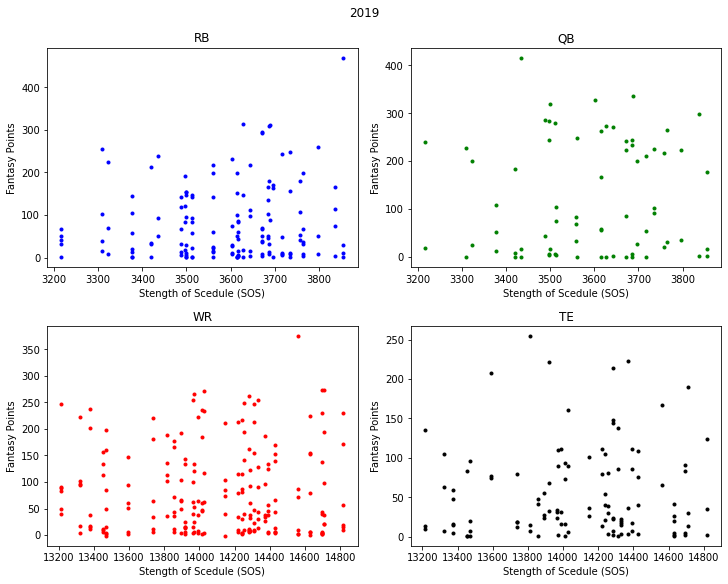

```python
fignum = 1

for year in range(2013, 2020):
  # get the data for that year
  yearly_data = get_yearly_data(year)
  # don't include players that haven't played this season
  yearly_data = yearly_data.loc[(yearly_data['FantasyPoints'] != 0)]
  # don't include players that are not on only one team for the whole season
  yearly_data = yearly_data.loc[yearly_data['Tm'].isin(team_abrv_list)]

  sos_df = get_sos_data(year)

  fig, axes = plt.subplots(2, 2, constrained_layout = True)
  fig.set_size_inches(10,8)
  for idx, row in yearly_data.iterrows():
    team_abrv = row['Tm']
    sos = -1
    if row['Pos'] == 'RB':
      for idx, sos_row in sos_df.iterrows():
        if team_abrv_dict[sos_row['Team']] == team_abrv:
          sos = sos_row['OppPassingFantasyPointsAllowed']
      axes[0, 0].plot(sos, row['FantasyPoints'], 'b.')
    elif row['Pos'] == 'WR':
      for idx, sos_row in sos_df.iterrows():
        if team_abrv_dict[sos_row['Team']] == team_abrv:
          sos = sos_row['OppPPRReceivingFantasyPointsAllowed']
      axes[1, 0].plot(sos, row['FantasyPoints'], 'r.')
    elif row['Pos'] == 'QB':
      for idx, sos_row in sos_df.iterrows():
        if team_abrv_dict[sos_row['Team']] == team_abrv:
          sos = sos_row['OppPassingFantasyPointsAllowed']
      axes[0, 1].plot(sos, row['FantasyPoints'], 'g.')
    elif row['Pos'] == 'TE':
      for idx, sos_row in sos_df.iterrows():
        if team_abrv_dict[sos_row['Team']] == team_abrv:
          sos = sos_row['OppPPRReceivingFantasyPointsAllowed']
      axes[1, 1].plot(sos, row['FantasyPoints'], 'k.')

  # label the figure appropriately
  fig.suptitle(year)
  axes[0, 0].set_title('RB')
  axes[0, 1].set_title('QB')
  axes[1, 0].set_title('WR')
  axes[1, 1].set_title('TE')
  for ax in axes.flat:
    ax.set(xlabel='Stength of Scedule (SOS)', ylabel='Fantasy Points')
  plt.show()
```

To our suprise we did not see any corelation between the strength of schedule and a players fantasy success at least on their success over the whole year. Since we don't see any kind of corelation this data is not fit for creating a linear or any other kind of model.

### ADP Value

Another key factor in fantasy football success is the draft. The draft is where you can get most of the good players and most league members keep the players they draft for the entire season so selecting a good lineup on draft day is crucial to success.

In fantasy football, a player's average draft position (ADP) refers to the average position in which they were taken from a large sample of draft data. This is a good metric to describe the projected value of a player on draft day. But how well does this correspond to actual performance? This is something we want to find out.

Let's make a prediction first. We should expect a player who is drafted earlier to get more fantasy points that season, right? So we predict a negative correlation between draft position and fantasy points. That is, as draft position increases, total fantasy points should decrease.  
*Takeaway: Make predictions about the data before we plot! That way, we can compare actual results to our expected results and think about why they might be different!*

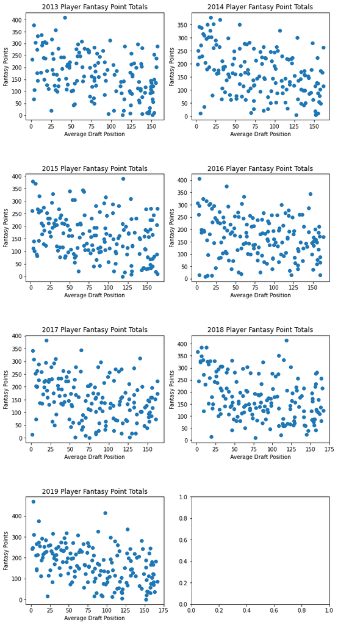

```python
all_years_df = []
fig, axs = plt.subplots(nrows=4,ncols=2,figsize=(10,20), constrained_layout = True)
plt.subplots_adjust(hspace=0.5)
for year, ax in zip(range(2013, 2020),axs.ravel()):
  adp_df = get_adp_by_year(year)
  year_df = get_yearly_data(year)
  year_df.rename(columns={'Tm':'Team'},inplace=True)

  # merge the data frames
  year_df = year_df.merge(adp_df, on=['Player'], how='inner')

  # save the merged dataframe in a list
  all_years_df.append(year_df)

  # plot the data
  ax.scatter(year_df['Overall'],year_df['FantasyPoints'])
  ax.set_xlabel('Average Draft Position')
  ax.set_ylabel('Fantasy Points')
  ax.set_title(str(year) + ' Player Fantasy Point Totals')
plt.show()
```

Our expected result was a decreasing linear correlation. That is, as a player's draft position increases, their total fantasy points should decrease. However, since a player's draft position is based on a player's *predicted* season totals, we know that we will not see a perfect correlation. Let's fit a linear model to this data and see if there is a correlation between draft position and fantasy points.

[figure not shown]

```python
fig, axs = plt.subplots(nrows=4,ncols=2,figsize=(10,20), constrained_layout = True)
plt.subplots_adjust(hspace=0.5)
for year, year_df, ax in zip(range(2010, 2021),all_years_df,axs.ravel()):
  ax.scatter(year_df['Overall'], year_df['FantasyPoints'])
  ax.set_xlabel('Average Draft Position')
  ax.set_ylabel('Fantasy Points')
  ax.set_title(str(year) + ' Player Fantasy Point Totals vs Draft Position')


  #Add linear regression line
  b,a = np.polyfit(list(year_df['Overall']),list(year_df['FantasyPoints']),deg=1)
  x_seq = np.linspace(0, 175, 176)
  ax.plot(x_seq,a+b*x_seq,color='red')
plt.show()
```

We do indeed see a negative correlation between draft position an fantasy points, as expected. What does this mean for the average fantasy player? After all, the purpose of using data science is to help make predictions about player performance! Specifically, we as fantasy players are interested in the players which fall *above* the regression line. These are the players who performed better than the model suggested!

In the next section, we will take a closer look at the players who consistently were above the regression line.

## Part 4: Hypothesis Testing

From our exploratory data analysis, we were able to narrow down our focus to players who were consistently above the regression line between Average Draft Position and total fantasy points. These players are the ones who we want to have our eyes on in the draft, because they consistently outperform expectations.  
*Takeaway: Use the insights gained from exploratory data analysis to narrow down your objective!*

At this point, we should determine a specific metric to use to evaluate player performance which relates to our analysis up to this point. One thing which we haven't discussed up to this point is measuring *distance* from the regression line. In statistics, the distance from the actual value to the expected value is known as a *residual*. Residuals can be positive or negative, and can tell us how good of a predictor our model is. In this case, residual values will tell us how much an individual player exceeds or does not exceed expectations. Read more about linear regressions and residuals [here](https://www.statology.org/linear-regression-assumptions/).

To this end, we will develop a metric which is the normalized sum of a player's residual value between ADP and total fantasy points across a certain number of seasons. *Normalizing* in statistics means adjusting values to be on a common scale. In this case, we will divide the sum of residuals by the number of seasons they have played. This is important because we want to be able to judge players who have played for a long time and those who are new to the NFL in a similar manner.

```python
#Add columns in our dataframe for "Predicted Fantasy Points" and "Residual Value"
prediction_df_list = []
for year_df in all_years_df:
  year_df = year_df.assign(FP_Predict = lambda x: (a + b*x['Overall']))
  year_df = year_df.assign(Resid = lambda x: (x['FantasyPoints'] - x['FP_Predict']))
  prediction_df_list.append(year_df)
```

```python
prediction_df = pd.concat(prediction_df_list)
names = []
norms = []
# positions = []
for player, group in prediction_df.groupby('Player'):
  sum_of_resid = group['Resid'].agg(np.sum)
  length = len(group)
  norm_sum_of_resid = sum_of_resid/length

  names.append(player)
  norms.append(norm_sum_of_resid)

  # positions.append(postition)
rank = [i for i in range(0,len(norms))]
value_df = pd.DataFrame(list(zip(names, norms)), columns =['Player', 'Residuals'])
value_df = value_df.sort_values('Residuals', ascending=False)
#value_df['ModelRank'] = rank
value_df
```

|  | Player | Residuals |
| --- | --- | --- |
| 249 | Lamar Jackson | 257.252462 |
| 306 | Patrick Mahomes | 168.971970 |
| 91 | Dak Prescott | 162.869291 |
| 209 | Josh Allen | 161.926087 |
| 76 | Christian McCaffrey | 136.285321 |
| ... | ... | ... |
| 406 | Zac Stacy | -144.972454 |
| 307 | Paul Perkins | -147.961759 |
| 398 | Vick Ballard | -152.568458 |
| 66 | Charles Johnson | -164.955141 |
| 112 | David Wilson | -195.874794 |

411 rows × 2 columns

Now we have an official ranking of players based on the metric we have created. We see that Lamar Jackson is by far the most valuable (and consistent) fantasy player, according to our metric. So why isn't he the first player drafted every year?

Great! We have some results. Are we done? Of course not! Now, we have to have some kind of way of testing the validity of our results, or else we have no credibility to back up our model!

There are many methods we can use to test our results. The method we will use is called "hold-out validation". Notice how we didn't use our data from the 2020 season to develop our model? That is because we initially decided that this data set would be used to validate our model. In what is known as "supervised machine learning", we train the data on a set or part of the set (70% of the total data is a typical value), and then use the remainder to validate our results. A comprehensive guide to machine learning can be found [here](http://ciml.info/).

We will use our data from the hold-out set to test the accuracy of our predictions. If our predictions are 100% accurate, then every result from our model should match with the fantasy point rankings in 2020. We already know that this can't be the case, because certain players which are included in our model have retired and there are new players who have been drafted in 2020 who are not present in our model. The solution would be to only keep the players which are shared by both DataFrames.

```python
#Read in validation set
validation_df = get_yearly_data(2020)
validation_df = validation_df.sort_values('FantasyPoints',ascending=False)

#Add ADP to validation set
adp_df = get_adp_by_year(2020)
validation_df = validation_df.merge(adp_df,on='Player',how='inner')
#validation_df

#Compute residuals in the validation set
b,a = np.polyfit(list(validation_df['Overall']),list(validation_df['FantasyPoints']),deg=1)

validation_df = validation_df.assign(FP_Predict = lambda x: (a + b*x['Overall']))
validation_df = validation_df.assign(Resid_2020 = lambda x: (x['FantasyPoints'] - x['FP_Predict']))

#validation_df['2020Rank']

total_df = value_df.merge(validation_df,on='Player',how='inner')
drop_list = ['Tm','Pos_x','Age','G','GS','Tgt','Rec','PassingYds',
             'PassingTD','PassingAtt','RushingYds','RushingTD',
             'RushingAtt','ReceivingYds','ReceivingTD','Int','Fumbles',
             'FumblesLost','#','Pick','Pos_y','Team','Overall','StdDev','High','Low','TimesDrafted']


total_df.drop(columns=drop_list,inplace=True)

#Create ranking metrics
rank = [i for i in range(0,len(total_df))]
total_df = total_df.sort_values('Residuals',ascending=False)
total_df['ModelRank'] = rank
total_df = total_df.sort_values('Resid_2020',ascending=False)
total_df['2020Rank'] = rank
total_df
```

|  | Player | Residuals | FantasyPoints | FP_Predict | Resid_2020 | ModelRank | 2020Rank |
| --- | --- | --- | --- | --- | --- | --- | --- |
| 3 | Josh Allen | 161.926087 | 395.0 | 119.858537 | 275.141463 | 3 | 0 |
| 28 | Aaron Rodgers | 62.184043 | 382.0 | 123.603361 | 258.396639 | 28 | 1 |
| 10 | Ryan Tannehill | 113.423453 | 343.0 | 91.304249 | 251.695751 | 10 | 2 |
| 6 | Kyler Murray | 131.280993 | 379.0 | 140.090992 | 238.909008 | 6 | 3 |
| 7 | Deshaun Watson | 127.080178 | 369.0 | 136.606225 | 232.393775 | 7 | 4 |
| ... | ... | ... | ... | ... | ... | ... | ... |
| 51 | Tarik Cohen | 25.202510 | 12.0 | 128.648472 | -116.648472 | 51 | 121 |
| 15 | Michael Thomas | 97.169657 | 44.0 | 169.737520 | -125.737520 | 15 | 122 |
| 86 | Marlon Mack | -8.990828 | 6.0 | 133.849617 | -127.849617 | 86 | 123 |
| 32 | Courtland Sutton | 57.824372 | 7.0 | 142.431507 | -135.431507 | 32 | 124 |
| 21 | Saquon Barkley | 82.091489 | 9.0 | 171.349875 | -162.349875 | 21 | 125 |

126 rows × 7 columns

Now, we have computed the residual value for each player in the 2020 season. We are also able to see the difference in "rank" between our training and test sets.

Let's take an aside for a moment. We spoke previously about different methods of validation. Another great validation method to use with this particular dataset would be K-Fold Cross Validation. It is similar to what we did above, except we would do the above steps "K" times, each time holding out the "Kth" season's data. Then, we could average our results and determine the players which are the most valuable on draft day, which may be different from our model above.

```python
y_true = list(total_df['Resid_2020'])
y_pred = list(total_df['Residuals'])
error = mean_absolute_error(y_true,y_pred)
error
```

```
62.911390104082805
```

Let's try computing the error between our "rank" columns, because that is what we are most concerned about when thinking about draft order.

```python
y_true = list(total_df['2020Rank'])
y_pred = list(total_df['ModelRank'])
error = mean_absolute_error(y_true,y_pred)
error
```

```
30.77777777777778
```

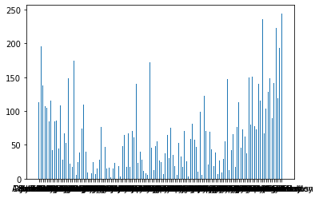

```python
fig, ax = plt.subplots()
ax.bar(total_df['Player'],abs(total_df['Resid_2020'] - total_df['Residuals']),width=0.4)
plt.show()
```

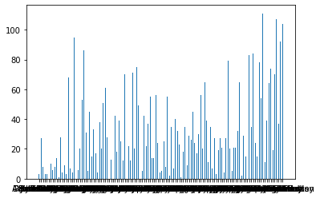

```python
fig, ax = plt.subplots()
ax.bar(total_df['Player'],abs(total_df['2020Rank'] - total_df['ModelRank']),width=0.4)
plt.show()
```

It doesn't seem as though our model does a very good job of prediction with these metrics. That may be okay! If you think about it, we are trying to measure which players would be good draft picks. We determined that players above the regression line were good value picks, and players below the line were not so good. So, if a player is on the same side of the line (either above or below) in both the train and test sets, we should consider our model somewhat of a success. Let's look into this.

```python
Resid_Loc_Test = []
Resid_Loc_Train = []

for i, row in total_df.iterrows():
  if row['Residuals'] >= 0:
    Resid_Loc_Train.append('Pos')
  else:
    Resid_Loc_Train.append('Neg')

  if row['Resid_2020'] >= 0:
    Resid_Loc_Test.append('Pos')
  else:
    Resid_Loc_Test.append('Neg')

total_df['Resid_Loc_Test'] = Resid_Loc_Test
total_df['Resid_Loc_Train'] = Resid_Loc_Train
total_df
```

|  | Player | Residuals | FantasyPoints | FP_Predict | Resid_2020 | ModelRank | 2020Rank | Resid_Loc_Test | Resid_Loc_Train |
| --- | --- | --- | --- | --- | --- | --- | --- | --- | --- |
| 3 | Josh Allen | 161.926087 | 395.0 | 119.858537 | 275.141463 | 3 | 0 | Pos | Pos |
| 28 | Aaron Rodgers | 62.184043 | 382.0 | 123.603361 | 258.396639 | 28 | 1 | Pos | Pos |
| 10 | Ryan Tannehill | 113.423453 | 343.0 | 91.304249 | 251.695751 | 10 | 2 | Pos | Pos |
| 6 | Kyler Murray | 131.280993 | 379.0 | 140.090992 | 238.909008 | 6 | 3 | Pos | Pos |
| 7 | Deshaun Watson | 127.080178 | 369.0 | 136.606225 | 232.393775 | 7 | 4 | Pos | Pos |
| ... | ... | ... | ... | ... | ... | ... | ... | ... | ... |
| 51 | Tarik Cohen | 25.202510 | 12.0 | 128.648472 | -116.648472 | 51 | 121 | Neg | Pos |
| 15 | Michael Thomas | 97.169657 | 44.0 | 169.737520 | -125.737520 | 15 | 122 | Neg | Pos |
| 86 | Marlon Mack | -8.990828 | 6.0 | 133.849617 | -127.849617 | 86 | 123 | Neg | Neg |
| 32 | Courtland Sutton | 57.824372 | 7.0 | 142.431507 | -135.431507 | 32 | 124 | Neg | Pos |
| 21 | Saquon Barkley | 82.091489 | 9.0 | 171.349875 | -162.349875 | 21 | 125 | Neg | Pos |

126 rows × 9 columns

Now, our problem can be treated more like a classification one. Let's try computing the precision and recall scores.

```python
y_true = total_df['Resid_Loc_Test']
y_pred = total_df['Resid_Loc_Train']
recall = recall_score(y_true,y_pred,average='micro')
precision = precision_score(y_true,y_pred,average='micro')
print(f'Recall score: {recall}')
print(f'Precision score: {precision}')
```

```
Recall score: 0.5952380952380952
Precision score: 0.5952380952380952
```

## Part 5: Conclusion and Discussion of Insights

### Discussion on Strength of Scehdule Results

In the fantasy football experts and analysts will often tell you to start players who have the best matchups which is why we decide to look at the correlation between strength of schedule and fantasy points. Based on our results we saw no correlation which contrasts what we expected to see. One improvement on our experiment that we could do is to analyze the data on a week by week basis since the experts recommendations are always on a week by week basis. If we were to compare a players success against their opponent's defensive strength for each week we may come up with different results that we were unable to find with the data we had. This expiriment may provide us with better insight into what our original motivation for looking into this data.

### Discussion on ADP Value Results

For the second part of our project we tried ot develop a model that helps decide who a good draft pick is based on the amount of points a player scores and where they were selected in the draft. A very valuable player is one that you draft later in the draft but still scores a lot of points. Our model created a linear regression to predict how many points a player would score based on their average draft position and then found the residuals of that model. Then using those residuals over the years tried to predict who would be a good draft pick for the upcoming year. We used data from 2013-2019 to develop our model and tested our predictions against the 2020 data that we had and found that our model was not very successful. We used a number of metrics to validate and got poor results. We have a few suggestions for future studies:

- Split up dataset by position. The data seems to be skewed heavily by quarterbacks, who frequent the top of the list.
- Try a different validation technique or model selection technique. We may indeed discover that something like K-folds would help to refine our model further.
- Try to better explain *why* players were above the line. We spent a lot of time trying to predict which players would be above the line, but didn't spend a lot of time looking at other features which might explain these trends.
- Use a different model entirely. Maybe ascribing everything to a magical regression line is not the best model for deciding which players are the best draft picks. In future studies, it would be helpful to think about this.

### Conclusions

Fantasy football is not an exact science. It is incredibly difficult to develop models to predict player performance, especially when factors like injuries or overall team performance can affect a player's performance in any given season. We believe that with further research and analysis, we would be able to refine our model and make great predictions about the players we want to draft.